# IAV_Analysis

## Gene Ontology

-Output the IDed proteins as a CSV of the Accession numbers. This file will be input into the tools on pantherdb.org

```r
write_csv(data_frame(Accession = filter3$Accession), here("Annotations", "all_iav_hits.csv"))
```

-Settings for pantherdb.org (April 10th, 2019): 1. Enter hits file 2. Select “homo sapiens” 3. Select “Statistical overrepresentation test” and default settings 4. Submit 5. Select GO molecular function or GO biological process 6. Fisher’s exact test 7. Use bonferroni correction 8. Run analysis 9. Export files. Located in “Annotations” folder (IAV_molecularfunction.txt, IAV_biologicalprocess.txt)

Graph - *Remove “Unclassified” annotation prior to ggplot

```r
molec <- read_tsv(here("Annotations", "IAV_molecularfunction.txt"), skip = 12)
biol <- read_tsv(here("Annotations", "IAV_biologicalprocess.txt"), skip = 12)
```

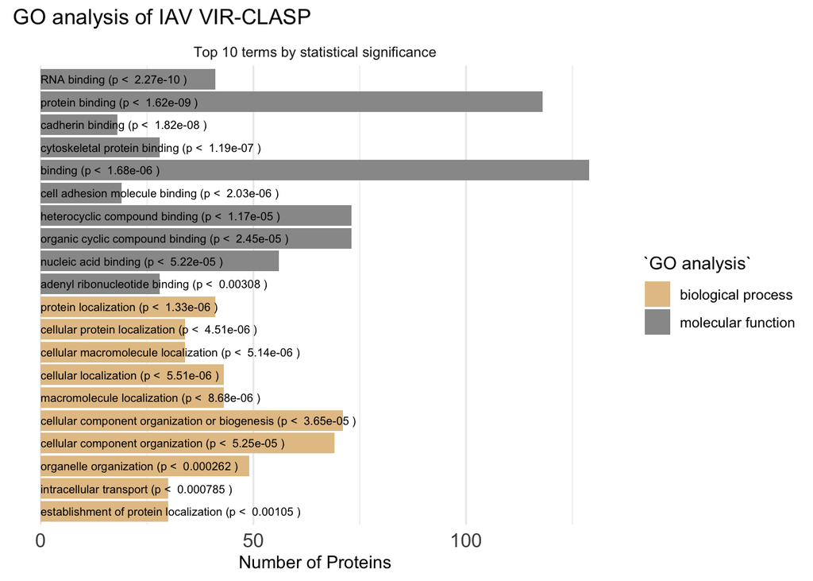

```r
colnames(molec)[1] <- "GO type"
colnames(biol)[1] <- "GO type"

molec_top <- molec %>%
  filter(`GO type` != "Unclassified (UNCLASSIFIED)") %>%
  top_n(n = -10, wt = `all_iav_hits.csv (P-value)`) %>%
  mutate(`GO analysis` = "molecular function")

biol_top <- biol %>%
  filter(`GO type` != "Unclassified (UNCLASSIFIED)") %>%
  top_n(n = -10, wt = `all_iav_hits.csv (P-value)`) %>%
  mutate(`GO analysis` = "biological process")

biol_virus <- biol %>%
  filter(`GO type` ==  "antigen processing and presentation (GO:0019882)" | grepl("viral", `GO type`)) %>%
  mutate(`GO analysis` = "biological process") %>%
  mutate(facets = "ZOther enriched terms")

combined_go <- rbind(molec_top, biol_top) %>%
  mutate(facets = "Top 10 terms by statistical significance") %>%
  rbind(biol_virus) %>%
  mutate(`GO type` = gsub("\\s*\\([^\\)]+\\)", "", `GO type`)) %>%
  arrange(`GO analysis`, desc(`all_iav_hits.csv (P-value)`)) %>%
  mutate(`GO type` = paste(`GO type`, "(p < ", `all_iav_hits.csv (P-value)`, ")")) %>%
  mutate(`GO type` = forcats::fct_inorder(factor(`GO type`)))

cbPalette <- c("#e5c494", "#999999")


ggplot(combined_go, aes(x = `GO type`, y = `all_iav_hits.csv (138)`, fill = `GO analysis`)) +
  geom_bar(stat = 'identity') +
  coord_flip() +
  scale_fill_manual(values=cbPalette) +
  geom_text(aes(label = `GO type`, y = 0, hjust = 0), size = 2.5) +
  theme_minimal() +
  theme(axis.text.x = element_text(size = 12),
        axis.text.y = element_blank(),
        axis.title.y = element_blank(),
        panel.grid.major.y = element_blank(),
        strip.text.y = element_text(size = 12)) +
  labs(y = "Number of Proteins", title = "GO analysis of IAV VIR-CLASP") +
  facet_wrap(~facets, ncol = 1)
```

```r
ggsave(here("Figures", "IAV_GO_041119.pdf"))
```

## Overlaps with previous RBP annotations

### Gerstberger Compilation

- See rtf in “Annotations” folder for explanation of Gerstberger dataset

```r
gerstberger <- read_csv(here("Annotations","Gerstberger_Uniprot.csv")) %>%
  filter(Status == "reviewed") %>%
  select("Accession" = Entry)
```

### GO RNA-binding annotations

- Retrieved from geneontology.org on 05/03/18

```r
go_rbp <- read_tsv(here("Annotations","RNA_binding_GO_050318.txt"), col_names = c("Accession", "Name"))
go_rbp$Accession <- gsub(pattern = "UniProtKB\\:", go_rbp$Accession, replacement = "")
go_rbp$Name = NULL
```

### Castello Interactome

- Same protocol as Gerstberger, Ensembl ID’s were converted to current version, then converted to Uniprot ID`s for comparison

```r
castello <- read_csv(here("Annotations", "HeLaInteractome_uniprot.csv"), col_names = "Accession")
```

### Baltz Interactome

```r
baltz <- read_csv(here("Annotations", "Baltz_uniprot.csv")) %>%
  select(Accession = Entry)
```

## Comparisons between Vir-CLASP, GO Annotated RBP’s, Gerstberger RBP’s, Castello RBP’s, and Baltz RBP’s

```r
iav_annotated <- filter3 %>%
  filter(Accession %in% go_rbp$Accession |
           Accession %in% gerstberger$Accession |
           Accession %in% castello$Accession |
           Accession %in% baltz$Accession)
print(paste("Number of annotated RBPs: ", n_distinct(iav_annotated$Accession)))
```

```
## [1] "Number of annotated RBPs:  44"
```

```r
iav_unannotated <- filter(filter3, !(Accession %in% go_rbp$Accession) &
                                 !(Accession %in% gerstberger$Accession) &
                                 !(Accession %in% castello$Accession &
                                     !(Accession %in% baltz$Accession)))
print(paste("Number of unannotated RBPs: ", n_distinct(iav_unannotated$Accession)))
```

```
## [1] "Number of unannotated RBPs:  95"
```

## Comparisons to VIR-CLASP with CHIKV (see other repository, CHIKV_VIRCLASP_Analysis)

```r
chikv <- readRDS(here("CHIKV", "CHIKV_Hits.rds"))

overlap_iav_chikv <- filter3 %>%
  filter(Accession %in% chikv$Accession)

n_distinct(overlap_iav_chikv$Accession)
```

```
## [1] 74
```

```r
write_csv(data_frame(Accession = overlap_iav_chikv$Accession), here("CHIKV", "overlap_iav_chikv.csv"))

iav_only <- filter3 %>%
  filter(!(Accession %in% chikv$Accession))

write_csv(data_frame(Accession = iav_only$Accession), here("CHIKV", "iav_only_hits.csv"))

n_distinct(iav_only$Accession)
```

```
## [1] 65
```

```r
chikv_only <- chikv %>%
  filter(!(Accession %in% filter3$Accession))

write_csv(data_frame(Accession = chikv_only$Accession), here("CHIKV", "chikv_only_hits.csv"))

n_distinct(chikv_only$Accession)
```

```
## [1] 234
```

```r
venn.plot <- venn.diagram(
  x = list(
    "IAV" = unique(filter3$Accession),
    "CHIKV" = unique(chikv$Accession)
  ),
  filename = NULL,
  scaled = TRUE,
  main = "VIR-CLASP Hits"

)

pdf(file = here("Figures", "IAV_CHIKV_Venn.pdf"))
  grid.draw(venn.plot)
dev.off()
```

## Supplementary Table generation

```r
sup_table_all <- filter3 %>%
  select(-ID, -source) %>%
  mutate(Name = str_extract(Description, "GN=[a-zA-Z0-9]* ")) %>%
  mutate(Name = str_trim(gsub("GN=", "", Name))) %>%
  unique()

write_tsv(sup_table_all, here("Supplementary Tables", "Sup_Table_all_IAV.tsv"))


rbp_sources <- bind_rows("GO: RNA-binding" = go_rbp,
                         "Gerstberger 2014" = gerstberger,
                         "Castello 2012" = castello,
                         "Baltz 2012" = baltz, .id = "Source")

sup_table_rbp <- rbp_sources %>%
  filter(Accession %in% filter3$Accession) %>%
  full_join(iav_annotated, by = "Accession") %>%
  mutate(Name = str_extract(Description, "GN=[a-zA-Z0-9]* ")) %>%
  mutate(Name = str_trim(gsub("GN=", "", Name))) %>%
  select(Accession, Name, Description, Source) %>%
  unique() %>%
  mutate(exists = "X") %>%
  spread(Source, exists, fill = "")

write_tsv(sup_table_rbp, here("Supplementary Tables", "Sup_Table_IAV_rbps.tsv"))
```